# Social Network Analysis R Tutorial Part 7: Tapered ERGM Modeling, Social Balance and Transitivity, and MCMC Diagnostics

- Show All Code
- Hide All Code
- View Source

R

SNA

Author

Shuhan (Alice) Ai

Published

November 17, 2025

Welcome to Part 7 of our Social Network Analysis R Tutorial series! In our [previous tutorial (Part 6)](https://aliceaii.github.io/posts/snapart6/), we explored the theoretical foundations of ERGMs, understanding the mathematical framework behind these powerful models. We covered the exponential family form, sufficient statistics, and the challenges of model degeneracy.

In this post, we will advance into **sophisticated ERGM modeling** by incorporating complex structural terms that capture network dependencies beyond simple dyadic relationships. We’ll explore geometrically weighted statistics, perform comprehensive MCMC diagnostics, and learn to interpret results in meaningful sociological contexts.

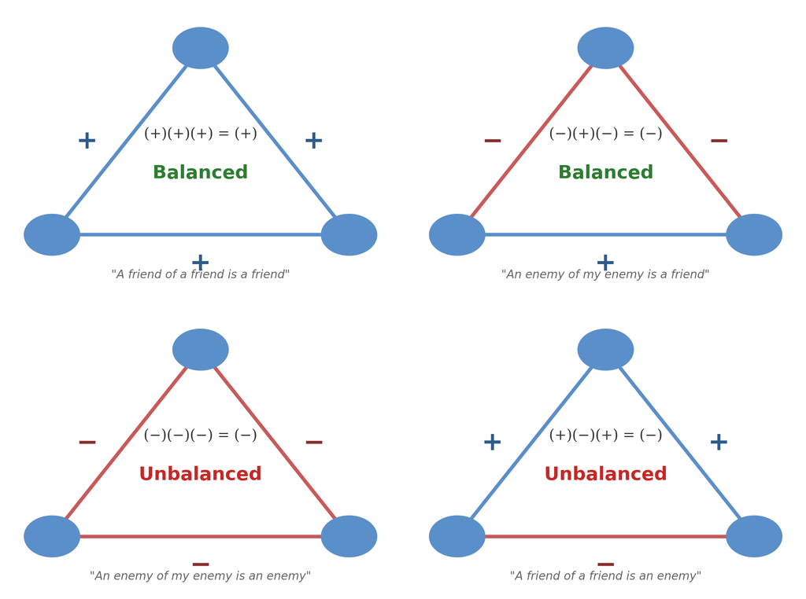

After completing this tutorial, you will be able to:

- Implement advanced structural terms in ERGM models (GWESP, GWDSP, triadic structures)
- Perform and interpret MCMC convergence diagnostics
- Compare nested models and assess model fit
- Interpret complex ERGM results in substantive terms
- Handle model degeneracy using **tapered ERGMs**

```r
rm(list = ls())

library(network)        # Network object manipulation
library(ergm)           # ERGM fitting
library(networkdata)    # Network datasets
library(sna)            # Social network analysis tools
library(parallel)       # Speed up MCMC
library(ergm.tapered)   # Tapered ERGM for handling degeneracy
library(amen)
# Install ergm.tapered if needed
# devtools::install_github("statnet/ergm", ref="tapered")
```

**Note**

**Why ergm.tapered?**

The `ergm.tapered` package provides an alternative estimation method that better handles models with strong dependence between terms. When you include multiple structural terms (like gwesp and gwdsp), standard ERGM estimation can struggle with convergence. Tapered ERGM adds a “tapering” mechanism that helps stabilize estimation.

Software available on GitHub as ergm.tapered: https://github.com/statnet/ergm.tapered

You can use these following code to install `ergm` or `ergm.tapered`:

```
install.packages("ergm", repos="http://www.stat.ucla.edu/~handcock")
install.packages("ergm.tapered", repos="http://www.stat.ucla.edu/~handcock")
```

or

```
install.packages("devtools")
devtools::install_github("statnet/ergm.tapered")
```

## 1. Introduction for Advanced Structural Terms in ERGMs

### 1.1 Understanding Geometrically Weighted Statistics

Before diving into applications, let’s understand the sophisticated structural terms available in ERGMs. These terms capture complex network dependencies while avoiding the degeneracy issues that plague simpler specifications.

**Note**

**Why Geometrically Weighted Terms?** Traditional count statistics (like triangle counts) can lead to model degeneracy because they treat all configurations equally. Geometrically weighted terms apply **diminishing returns** - the first few shared partners matter more than additional ones, making the model more stable and interpretable.

### 1.2 Comprehensive Function Reference Table

Here’s a detailed reference table for advanced ERGM structural terms:

| Function | Syntax | Description | Interpretation | When to Use |
| --- | --- | --- | --- | --- |
| **istar(k)** | `istar(2)` | k-in-stars: counts nodes with exactly k incoming edges | Popularity effects in directed networks | Testing for preferential attachment to popular nodes |
| **ostar(k)** | `ostar(2)` | k-out-stars: counts nodes with exactly k outgoing edges | Activity effects in directed networks | Testing for variation in node activity levels |
| **gwodegree(decay)** | `gwodegree(0.5, fixed=TRUE)` | Geometrically weighted out-degree distribution | Controls out-degree heterogeneity with diminishing returns | Modeling sender activity patterns without degeneracy |
| **gwidegree(decay)** | `gwidegree(0.5, fixed=TRUE)` | Geometrically weighted in-degree distribution | Controls in-degree heterogeneity with diminishing returns | Modeling popularity/receiver effects without degeneracy |
| **gwesp(decay)** | `gwesp(0.5, fixed=TRUE)` | Geometrically weighted edgewise shared partners | Transitivity: “friend of friend is friend” with diminishing returns | Capturing clustering while avoiding degeneracy |
| **gwdsp(decay)** | `gwdsp(0.5, fixed=TRUE)` | Geometrically weighted dyadwise shared partners | Shared partners between any dyad (connected or not) | Modeling local clustering and “small world” effects |
| **ctriple** | `ctriple` or `ctriad` | Cyclic triples: A→B→C→A patterns | Non-hierarchical, cyclic relationships | Testing for cyclic vs hierarchical structures |
| **ttriple** | `ttriple` or `ttriad` | Transitive triples: A→B→C with A→C | Hierarchical, transitive closure | Testing for transitivity and balance theory |

**Tip**

Choosing Decay Parameters The decay parameter (α) in geometrically weighted terms controls how quickly the weight diminishes:

- **α = 0**: Only the first shared partner matters
- **α = 0.5**: Moderate decay (common choice)
- **α = 1.0**: Slower decay, more weight on higher numbers
- **α → ∞**: Approaches regular count statistics

Start with α = 0.5 as a default and adjust based on model diagnostics.

## 2. Tapered ERGM: Solving the Degeneracy Problem

### 2.1 Why We Need Tapered ERGM

One of the most frustrating challenges in ERGM modeling is **model degeneracy** (or near-degeneracy). This occurs when a model places almost all its probability mass on extreme network configurations—like empty graphs, complete graphs, or other boundary cases.

#### 2.1.1 The Triangle Problem

A classic example is the triangle model:

$$P_\eta(Y = y) = \frac{\exp\{\eta_1\text{edge}(y) + \eta_2\text{triangle}(y)\}}{c(\eta_1, \eta_2)}$$

This model is near-degenerate for most values of $\eta_2 > 0$. When we try to include theoretically meaningful terms like triangles, GWESP, or other clustering measures, the model often becomes unstable and produces unreliable results.

#### 2.1.2 Practical Constraints

Near-degeneracy has constrained practical ERGM modeling:

- **Limited term selection**: Many intuitive or theory-driven terms (like triangles) often cannot be used.
- **Model instability**: MCMC algorithms fail to converge or produce degenerate samples.
- **Multimodality**: The distribution over network statistics becomes bimodal or multimodal, making inference unreliable.

This is why we’ve had to be so careful about model specification in previous tutorials—we’ve been working around the degeneracy problem rather than solving it directly.

### 2.2 How Tapered ERGM Works

#### 2.2.1 The Model Specification

The Tapered ERGM has the form:

$$q(y|\theta, \tau) = \frac{1}{Z(\theta, \tau)} \exp\left\{\sum_k \theta_k g_k(y) - \sum_k \tau_k(\mu_k(\theta, \tau) - g_k(y))^2\right\}$$

where:

- $\theta$ = standard ERGM parameters (same interpretation as before)
- $\tau$ = tapering parameters (hyperparameters that control stability)
- $\mu(\theta, \tau) = E_q[g(Y)]$ = mean value parameters
- The second term $-\sum_k \tau_k(\mu_k - g_k(y))^2$ is the **tapering term**

The tapering term acts as a **soft constraint** that penalizes network configurations far from the mean $\mu$. Think of it as:

- An “attractive force” pulling the distribution toward its mode
- The strength of this force is controlled by $\tau_k$
- When $\tau = 0$, we recover the standard ERGM
- As $\tau$ increases, the model becomes more stable but potentially more biased

#### 2.2.2 Maximum Entropy Interpretation

The tapering term has a beautiful theoretical interpretation. The Tapered ERGM arises from a **constrained maximum entropy** problem:

$$\begin{align}
\text{maximize}_q &\quad -\sum_y q(y)\log(q(y)) \\
\text{subject to} &\quad E_q[g_i(Y,X)] = \mu_i \\
&\quad E_q[(\mu_i - g_i(Y,X))^2] \leq \sigma^2_i, \quad \forall i
\end{align}$$

In other words, we’re finding the distribution that: 1. Has maximum entropy (is least constrained) 2. Matches expected network statistics 3. **Also constrains the variance** of those statistics to be at most $\sigma^2_i$

This variance constraint is what prevents degeneracy.

### 2.3 Choosing the Tapering Parameters

#### 2.3.1 Parameter Interpretation

**When Tapering is Zero ($\tau = 0$)**

The model reduces to standard ERGM, and $\theta_k$ represents conditional log-odds as usual.

**When Tapering is Non-Zero ($\tau > 0$)**

The interpretation changes slightly. The conditional log-odds of a tie becomes:

$$\log\left(\frac{P(Y_{ij}=1|Y^c_{ij})}{P(Y_{ij}=0|Y^c_{ij})}\right) = \sum_k \Delta t_k(Y_{ij})[\theta_k + \tau_k \delta_{kij}]$$

The term $\tau_k \delta_{kij}$ represents a **bias** introduced by tapering. However, this bias:

- Is typically small when the model is well-specified
- Ensures computational stability
- Is a worthwhile trade-off for being able to use meaningful network terms

#### 2.3.2 Choosing the Tapering Parameters

How do we determine $\tau$? The lecture materials suggest using **kurtosis** as a measure of potential degeneracy:

$$\text{Kurt}[g(Y)] = \frac{\mu_4}{\mu_2^2} = E[Z^4] \text{ where } Z \text{ is standardized}$$

Key facts about kurtosis: - $\text{Kurt}[g(Y)] \geq 1$ always - Gaussian: $\text{Kurt} = 3$ - Uniform: $\text{Kurt} = 1.8$ - Higher kurtosis suggests bimodality/degeneracy

The tapering is determined by constraining variance:

$$V(\theta, \tau) = Var_q(g(Y)) = \sigma^2$$

The `ergm.tapered` package automatically estimates appropriate $\tau$ values based on: 1. The observed network statistics 2. Desired variance constraints 3. Ensuring non-degeneracy

Automatic Selection: in practice, the package `ergm.tapered()` will

- Usually choose standard ERGM ($\tau = 0$) when justified
- Only add tapering when needed for stability
- Balance bias-variance trade-off automatically

### 2.4 Summary: When to Use Tapered ERGM

**Use Tapered ERGM when (recommended):**

- You want to include theoretically important but potentially problematic terms (triangles, GWESP, etc.)
- Standard ERGM shows convergence issues or degeneracy warnings
- You need guaranteed computational stability
- You’re modeling larger networks where degeneracy is more likely

**Advantages:**

- Theoretical guarantee of non-degeneracy
- Minimal bias when standard ERGM would work
- Interpretable as constrained maximum entropy
- Available in user-friendly software (`ergm.tapered` package)

**Trade-offs:**

- Slight bias in parameter estimates (usually small)
- Additional hyperparameters ($\tau$) to consider
- Need to understand what tapering means for interpretation

The Tapered ERGM represents a major breakthrough in network modeling, finally allowing us to use the full richness of ERGM specifications without worrying too much about the degeneracy.

## 3. Case Study 1 - The French Financial Elite Network

### 3.1 The French Financial Elite Network Basic Information

We’ll work with a network collected by Charles Kadushin (1995) of 28 members of the French financial elite. This network captures friendship ties and includes rich vertex attributes that allow us to explore multiple dimensions of homophily.

**Data Source:**

Kadushin, C. 1995. Friendship among the French financial elite. *American Sociological Review* 60:202-221.

```r
data(ffef)
help(ffef)
network.size(ffef)
```

```
[1] 28
```

```r
network.edgecount(ffef)
```

```
[1] 66
```

```r
gden(ffef)
```

```
[1] 0.1746032
```

```r
list.vertex.attributes(ffef)
```

```
 [1] "birthdate"    "birthplace"   "cabinet"      "clubs"        "eliteprom"
 [6] "elitevote"    "ena"          "enayear"      "fathers-lev"  "finance-min"
[11] "igyear"       "inspec-gen"   "masons"       "na"           "normal-sch"
[16] "party"        "polytech"     "polyyear"     "prestige"     "religion"
[21] "sciencepoly"  "socialreg"    "topboards"    "university"   "vertex.names"
[26] "zipcode"
```

The network includes several important vertex covariates:

- **prestige**: 0 (neither particule nor social register), 1 (either), or 2 (both)
- **party**: Political party membership (11 parties)
- **ena**: Graduated from ENA (École nationale d’administration)? 1=yes, 2=no
- **masons**: Mason membership
- **religion**: Religious affiliation
- **topboards**: Number of top corporate boards

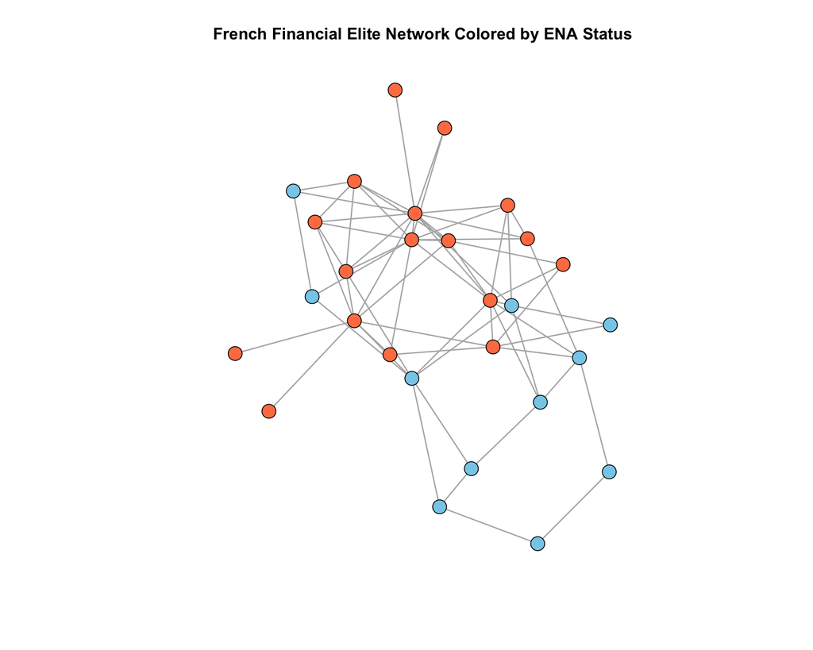

```r
ena_status <- ffef %v% "ena"
vertex_colors <- ifelse(ena_status == 1, "coral", "skyblue")

plot(ffef, vertex.col = vertex_colors,
     main = "French Financial Elite Network Colored by ENA Status",
     vertex.cex = 1.5, edge.col = "gray70")
```

**Observations:**

1. **Visible clustering by ENA attendance**: Individuals who graduated from ENA tend to form connections with other ENA graduates, suggesting strong educational homophily
2. **Centrality patterns**: ENA graduates appear more concentrated in the network core, while non-ENA graduates are more dispersed around the periphery
3. **Cross-group ties exist**: While there’s clear same-status clustering, we also observe connections between ENA and non-ENA graduates

### 3.2 Building a Sophisticated ERGM Model

```r
#using ergm.tapered() for better handling of strong dependencies
fit_elite <- ergm.tapered(
  ffef ~
    edges +                           # Baseline density
    nodematch("ena") +               # ENA homophily
    nodematch("prestige") +          # Prestige homophily
    nodematch("party") +             # Political party homophily
    gwesp(0.5, fixed = TRUE) +       # Transitive closure (clustering)
    gwdsp(0.5, fixed = TRUE),        # Shared partners
  verbose = FALSE
)

summary(fit_elite)
```

```
 Results:

                   Estimate Std. Error MCMC % z value Pr(>|z|)
edges               -4.7001     0.5183      0  -9.069  < 1e-04 ***
nodematch.ena        1.5578     0.3723      0   4.184  < 1e-04 ***
nodematch.prestige   0.6882     0.2696      0   2.553  0.01068 *
nodematch.party      1.2204     0.3775      0   3.233  0.00122 **
gwesp.fixed.0.5      0.4576     0.1870      0   2.447  0.01441 *
gwdsp.fixed.0.5      0.1890     0.0585      0   3.230  0.00124 **
---
Signif. codes:  0 '***' 0.001 '**' 0.01 '*' 0.05 '.' 0.1 ' ' 1
The estimated tapering scaling factor is 2.

     Null Deviance: 524.0  on 378  degrees of freedom
 Residual Deviance: 302.5  on 372  degrees of freedom

AIC: 314.5  BIC: 338.1  (Smaller is better. MC Std. Err. = 0)
```

### 3.3 Interpreting Model Coefficients

```r
coef_table <- data.frame(
  Term = names(coef(fit_elite)),
  Coefficient = round(coef(fit_elite), 3),
  SE = round(summary(fit_elite)$coefficients[, "Std. Error"], 3),
  OR = round(exp(coef(fit_elite)), 3),
  p_value = round(summary(fit_elite)$coefficients[, "Pr(>|z|)"], 4)
)

print(coef_table)
```

```
                                 Term Coefficient    SE    OR p_value
edges                           edges      -4.700 0.518 0.009  0.0000
nodematch.ena           nodematch.ena       1.558 0.372 4.748  0.0000
nodematch.prestige nodematch.prestige       0.688 0.270 1.990  0.0107
nodematch.party       nodematch.party       1.220 0.377 3.388  0.0012
gwesp.fixed.0.5       gwesp.fixed.0.5       0.458 0.187 1.580  0.0144
gwdsp.fixed.0.5       gwdsp.fixed.0.5       0.189 0.059 1.208  0.0012
```

```r
baseline_prob <- plogis(coef(fit_elite)["edges"])
ena_match_prob <- plogis(coef(fit_elite)["edges"] + coef(fit_elite)["nodematch.ena"])
prestige_match_prob <- plogis(coef(fit_elite)["edges"] + coef(fit_elite)["nodematch.prestige"])
party_match_prob <- plogis(coef(fit_elite)["edges"] + coef(fit_elite)["nodematch.party"])

cat("Baseline (no matches):", round(baseline_prob, 4), "\n")
```

```
Baseline (no matches): 0.009
```

```r
cat("Same ENA status:", round(ena_match_prob, 4), "\n")
```

```
Same ENA status: 0.0414
```

```r
cat("Same prestige level:", round(prestige_match_prob, 4), "\n")
```

```
Same prestige level: 0.0178
```

```r
cat("Same party affiliation:", round(party_match_prob, 4), "\n")
```

```
Same party affiliation: 0.0299
```

**Note**

```
plogis(coef["edges"] + coef["gwesp.fixed.0.5"])
```

**This does NOT work because:**

- GWESP is not a 0/1 indicator variable
- GWESP is a **count statistic** that depends on the entire network structure
- GWESP uses a **geometrically weighted** function: $\sum_{k=1}^{n-2} \{1 - (1-e^{-\alpha})^k\} \cdot EP_k$

Summary:

| Term Type | Example Terms | Can use `plogis(edges + term)`? | Why/Why not? |
| --- | --- | --- | --- |
| **Node attributes** | `nodematch()`, `nodecov()`, `absdiff()` | YES | Binary 0/1 or known numeric covariate values |
| **Dyad attributes** | `edgecov()`, `dyadcov()` | YES (with care) | Known covariate value for specific dyad |
| **Structural terms** | `gwesp()`, `gwdsp()`, `triangle`, `ttriad`, `ctriad` | NO | Value depends on entire network configuration |
| **Degree terms** | `gwdegree()`, `degree()`, `idegree()`, `odegree()` | NO | Depends on node’s position in network |

### 3.4 MCMC Diagnostics - Ensuring Model Reliability

```
Sample statistics summary:

Iterations = 44288:883200
Thinning interval = 256
Number of chains = 1
Sample size per chain = 3278

1. Empirical mean and standard deviation for each variable,
   plus standard error of the mean:

                      Mean     SD Naive SE Time-series SE
edges              -0.3630  3.661  0.06395        0.09034
nodematch.ena      -0.3606  3.915  0.06839        0.09562
nodematch.prestige -0.1062  3.324  0.05805        0.08624
nodematch.party    -0.1297  2.187  0.03820        0.06271
gwesp.fixed.0.5    -0.3343  6.492  0.11339        0.11354
gwdsp.fixed.0.5     0.1678 18.212  0.31810        0.35425

2. Quantiles for each variable:

                     2.5%     25%     50%    75% 97.5%
edges               -8.00  -3.000  0.0000  2.000  7.00
nodematch.ena       -8.00  -3.000  0.0000  2.000  7.00
nodematch.prestige  -7.00  -2.000  0.0000  2.000  7.00
nodematch.party     -4.00  -2.000  0.0000  1.000  4.00
gwesp.fixed.0.5    -13.37  -4.842 -0.2345  4.259 11.77
gwdsp.fixed.0.5    -34.65 -12.500  0.4226 12.589 34.76


Are sample statistics significantly different from observed?
                   edges nodematch.ena nodematch.prestige nodematch.party
diff.      -3.630262e-01 -0.3605857230         -0.1061623     -0.12965223
test stat. -4.018323e+00 -3.7710305013         -1.2310117     -2.06750444
P-val.      5.861388e-05  0.0001625748          0.2183185      0.03868665
           gwesp.fixed.0.5 gwdsp.fixed.0.5 Overall (Chi^2)
diff.         -0.334303154       0.1677735              NA
test stat.    -2.944470918       0.4736051    18.906636407
P-val.         0.003235073       0.6357815     0.004551536

Sample statistics cross-correlations:
```

[output cut: 34 more lines]

```

Fraction in 1st window = 0.1
Fraction in 2nd window = 0.5

             edges      nodematch.ena nodematch.prestige    nodematch.party
            0.4291            -0.5517            -1.0152             0.7064
   gwesp.fixed.0.5    gwdsp.fixed.0.5
            0.7667            -0.7362

Individual P-values (lower = worse):
             edges      nodematch.ena nodematch.prestige    nodematch.party
         0.6678823          0.5811682          0.3100284          0.4799360
   gwesp.fixed.0.5    gwdsp.fixed.0.5
         0.4432616          0.4616164
Joint P-value (lower = worse):  0.2416498 .
```

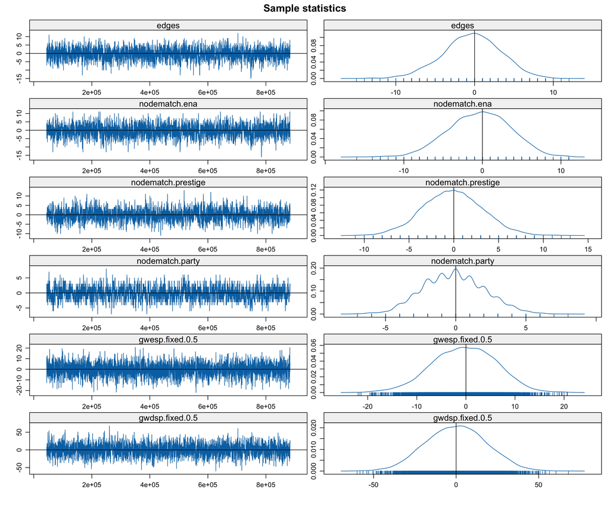

```
MCMC diagnostics shown here are from the last round of simulation, prior to computation of final parameter estimates. Because the final estimates are refinements of those used for this simulation run, these diagnostics may understate model performance. To directly assess the performance of the final…
```

```r
mcmc_diag <- mcmc.diagnostics(fit_elite, vars.per.page = 6)
```

**Note**

MCMC Diagnostic Components Explained:

- **Sample Statistics vs. Observed**: Compares simulated network statistics to observed values. Good fit shows statistics centered around zero.
- **Trace Plots**: Show MCMC chain values over iterations. Good mixing looks like “fuzzy caterpillar” around zero.
- **Density Plots**: Distribution of sampled statistics. Should be approximately normal and centered near zero.
- **Autocorrelation Function (ACF)**: Measures correlation between successive samples. Should decay quickly to near zero.
- **Geweke Diagnostic**: Tests whether early and late parts of chain come from same distribution (burn-in test).

Let’s extract some key diagnostic statistics:

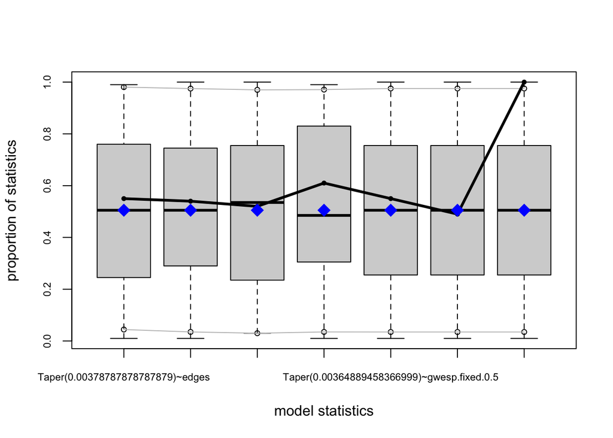

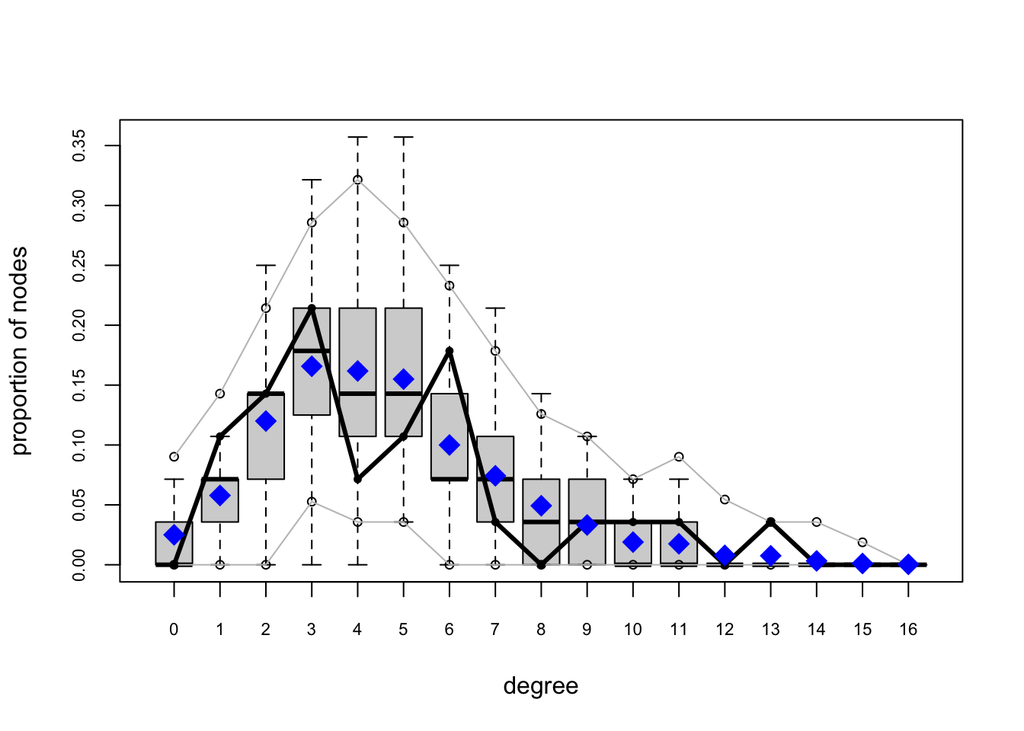

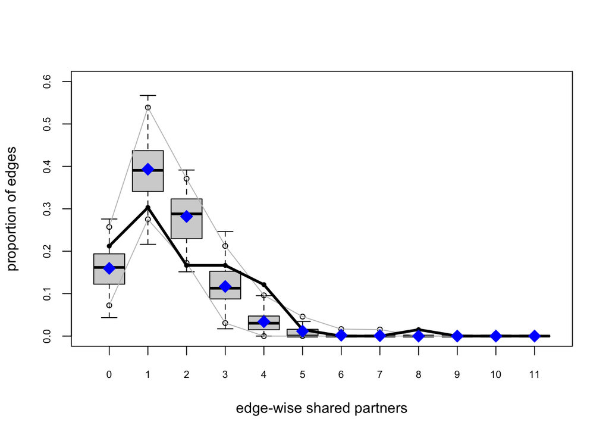

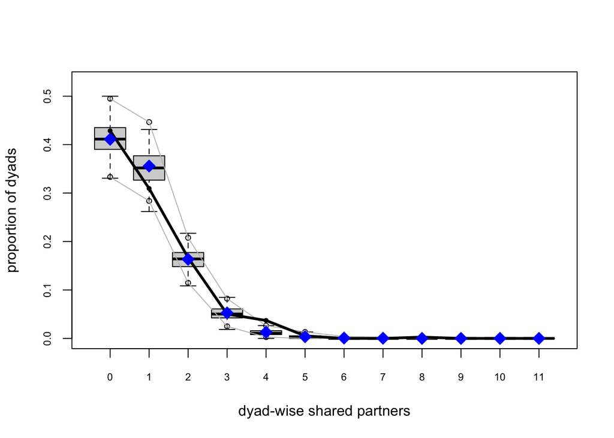

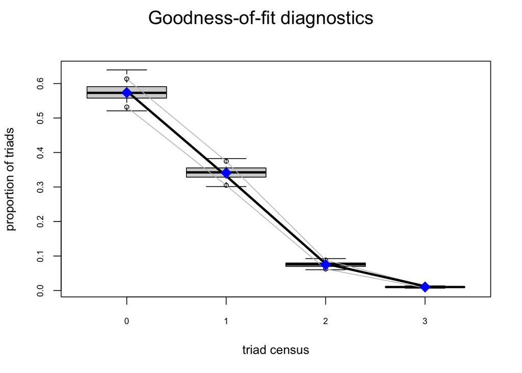

```r
gof_elite <- gof(fit_elite, GOF = ~degree + esp + dsp + triadcensus,
                 verbose = FALSE)
plot(gof_elite)
```

## 4. Social Balance and Transitivity in Network Analysis

### 4.1 Definition of Social Balance

Social balance and transitivity are concepts in network analysis that help us understand how relationships form and evolve in social networks. These concepts, rooted in social psychology and graph theory, provide insights into the micro-level mechanisms that shape macro-level network structures.

#### Heider’s Balance Theory

Fritz Heider’s balance theory examines relationships among three actors (P-O-X triads) where each dyadic relationship can be positive (+) or negative (-). According to Heider:

The key principle: **multiply the signs of all three edges**. If the product is positive, the triad is balanced; if negative, it’s unbalanced.

*The following plot shows the four foundamental triad configurations in balance theory. Balanced triads (top row) are psychologically stable, while unbalanced triads (bottom row) create cognitive tension that motivates relationship change.*

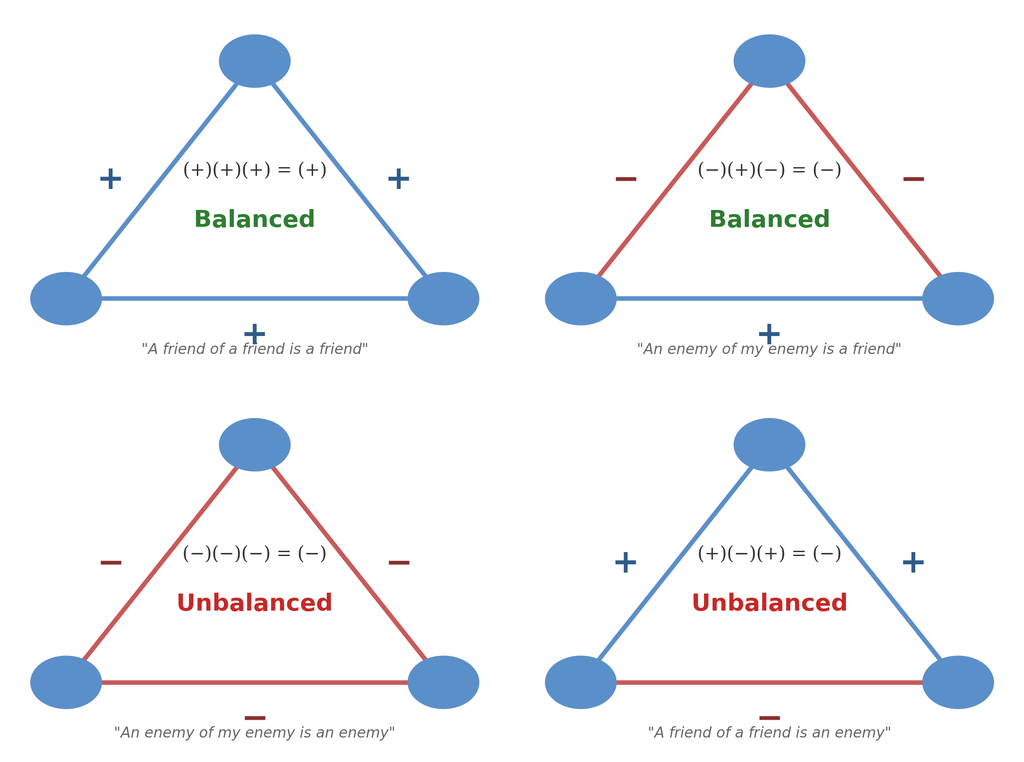

### 4.2 From Undirected to Directed Networks

While Heider’s original theory focused on undirected relationships, real social networks often involve directed ties (e.g., “A nominates B as a friend” doesn’t guarantee reciprocity). For directed networks, we use:

- **MAN notation**: Classifies triads by the number of Mutual, Asymmetric, and Null dyads
- **16 triad types**: From 003 (no connections) to 300 (completely connected), the following plots represent the 16 types
- **Notation** The first number represents the number of mutual (bidirectional) edges within the triad. These are pairs of vertices with a connection in both directions (e.g., A is connected to B, and B is connected to A). The second number in the three-digit code indicates the number of asymmetric (unidirectional) edges, and the third number represents the number of null (non-existent) edges.

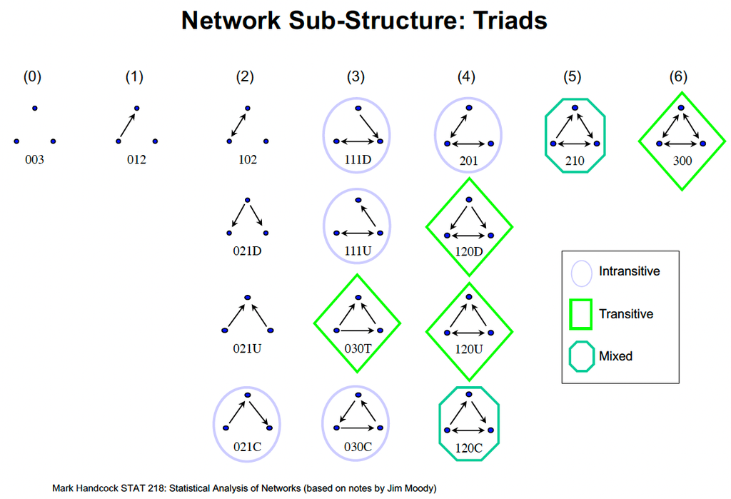

#### Transitivity in Directed Networks

Transitivity captures the “friend of a friend” phenomenon:

- If i → j and j → k, then i → k (transitive closure)
- **Transitive triads**: e.g., 030T, 120D, 120U, 300, indicate hierarchical or clustered structures
- **Intransitive triads** e.g., 111D, 111U, 030C, suggest competing relationships or ranked preferences
- **Cyclic triads** e.g.m 030C: A→B→C→A, represent circular patterns without hierarchical closure

### 4.3 Network-Level Implications

Balance theory has profound implications for understanding macro-level network structure:

1. **Clustered Communities**: If balance holds throughout a network, we expect clear group boundaries with positive ties within groups and negative ties between groups
2. **Structural Balance Theorem**: A completely balanced signed network must have one of two structures:
   - A single cohesive clique (all positive ties)
   - Two opposing factions (positive within, negative between)
3. **Weak Balance**: Real networks often show “weak balance” where the all-negative triad (-)(-)(-) is also allowed, permitting multiple clusters rather than just two factions

### 4.4 Measuring Balance in Real Networks

We can empirically test balance theory using:

- **Triad census**: Count the frequency of each triad type
- **Statistical comparison**: Compare observed counts to expected distributions under random graphs
- **ERGM terms**:
  - `ttriad` (transitive triads count)
  - `ctriad` (cyclic triads count)

## 5. Case Study 2 - Balance Theory in Hansell Classroom Friendships

Now let’s examine balance theory using directed friendship nominations in a sixth-grade classroom, we’ve used this dataset in the [previous tutorial (Part 5)](https://aliceaii.github.io/posts/snapart5/):

### 5.1 Is the friendship network balanced in Heider’s definition of balance?

**Tip**

**Heider’s Balance Theory** In a balanced network:

- **Transitive triads** (A→B→C implies A→C): “Friend of friend is friend”
- **Avoided cyclic triads** (A→B→C→A without A→C): Creates tension

Balanced networks have positive transitive triad coefficients and negative cyclic triad coefficients.

```r
library(networkdata)
data(hansell)
help(hansell)

#summary(hansell)
table(hansell %v% "sex")
```

```
female   male
    14     13
```

```r
triad.census(hansell)
```

```
     003 012 102 021D 021U 021C 111D 111U 030T 030C 201 120D 120U 120C 210 300
[1,] 771 982 248  234  115  150   68   97  126    2  13   32   32   20  28   7
```

```r
#transitive triads
triads <- triad.census(hansell)
triads[9]  # 030T
```

```
[1] 126
```

```r
#cyclic triads
triads[10]   # 030C
```

```
[1] 2
```

### 5.2 Fit the model

```r
fit_balance <- ergm.tapered(
  hansell ~
    edges +                          # Baseline density
    mutual +                         # Reciprocity
    nodematch("sex", diff = TRUE) +  # Sex homophily (differentiated)
    ttriple +                        # Transitive triples
    ctriple,                         # Cyclic triples
  verbose = FALSE
)

summary(fit_balance)
```

```
 Results:

                     Estimate Std. Error MCMC % z value Pr(>|z|)
edges                -3.07957    0.14316      0 -21.511   <1e-04 ***
mutual                0.26717    0.35500      0   0.753    0.452
nodematch.sex.female  0.88263    0.12282      0   7.186   <1e-04 ***
nodematch.sex.male    1.08242    0.15999      0   6.765   <1e-04 ***
ttriple               0.33155    0.01983      0  16.720   <1e-04 ***
ctriple              -0.40377    0.07693      0  -5.248   <1e-04 ***
---
Signif. codes:  0 '***' 0.001 '**' 0.01 '*' 0.05 '.' 0.1 ' ' 1
The estimated tapering scaling factor is 2.

     Null Deviance: 973.2  on 702  degrees of freedom
 Residual Deviance: 633.3  on 696  degrees of freedom

AIC: 645.3  BIC: 672.6  (Smaller is better. MC Std. Err. = 0)
```

```r
balance_coef <- data.frame(
  Term = c("Edges", "Mutual", "Same Sex (Female)", "Same Sex (Male)",
           "Transitive Triples", "Cyclic Triples"),
  Coefficient = round(coef(fit_balance), 3),
  OR = round(exp(coef(fit_balance)), 3))

print(balance_coef, row.names = FALSE)
```

```
               Term Coefficient    OR
              Edges      -3.080 0.046
             Mutual       0.267 1.306
  Same Sex (Female)       0.883 2.417
    Same Sex (Male)       1.082 2.952
 Transitive Triples       0.332 1.393
     Cyclic Triples      -0.404 0.668
```

**Important**

Evidence for Balance model

The model provides strong evidence for balance theory:

- **Positive transitivity** (β = 0.33, p < 0.05): Transitive closure is preferred
- **Negative cyclicity** (β = -0.40, p < 0.001): Cyclic patterns are avoided
- **Strong sex homophily**: Both boys and girls prefer same-sex friendships
- **No reciprocity effect**: Friendships aren’t necessarily mutual at this age

This pattern suggests the classroom network organizes into balanced, sex-segregated friendship groups with clear hierarchical structures rather than cyclic patterns.

- **Transitive ties (ttriple):** $\beta = 0.33$, the coefficient measures the tendency for transitive triadic closure in the network, it’s significant. The $OR = 1.39$ means that for each additional transitive triple configuration, the odds of the network configuration increased by 39%. When student A nominates student B as a friend, and B nominates C, there is a significantly higher-than-random probability that A will also nominate C. This creates cohesive friendship groups with closed triadic structures.
- **Cyclic ties (ctriple):** $\beta = -0.40$, the coefficient measures the tendency for cyclic triadic structures in the network, where: $A→B→C→A$ forms a cycle, but without the full transitive closure. The negative and highly significant coefficient (p < 0.001) indicates a strong avoidance of cyclic triadic structures. $OR = 0.67$ means that cyclic triple configurations decrease the odds of the network configuration by 33%. The negative coefficient shows that cyclic patterns are less common than would be expected in a random network.

### 5.3 Model Comparison and Selection

```r
# Fit alternative model for French elite network
fit_elite_extended <- ergm.tapered(
  ffef ~
    edges +
    nodematch("ena") +
    nodematch("prestige") +
    nodematch("party") +
    nodematch("masons") +           # Add Masonic membership
    nodematch("religion") +          # Add religion
    nodecov("topboards") +           # Board memberships as covariate
    absdiff("topboards") +           # Difference in board memberships
    gwesp(0.5, fixed = TRUE) +
    gwdsp(0.5, fixed = TRUE),
  verbose = FALSE
)

# Model comparison
anova_result <- anova(fit_elite, fit_elite_extended)
print(anova_result)
```

```
Analysis of Variance Table

Model 1: ffef ~ Taper(~edges + nodematch("ena") + nodematch("prestige") +
    nodematch("party") + gwesp(0.5, fixed = TRUE) + gwdsp(0.5,
    fixed = TRUE), coef = .taper.coef, m = .taper.center)
Model 2: ffef ~ Taper(~edges + nodematch("ena") + nodematch("prestige") +
    nodematch("party") + nodematch("masons") + nodematch("religion") +
    nodecov("topboards") + absdiff("topboards") + gwesp(0.5,
    fixed = TRUE) + gwdsp(0.5, fixed = TRUE), coef = .taper.coef,
    m = .taper.center)
     Df Deviance Resid. Df Resid. Dev Pr(>|Chisq|)
NULL                   378     524.02
1     6  221.506       372     302.51       <2e-16 ***
2     4   -0.225       368     302.74       0.9941
---
Signif. codes:  0 '***' 0.001 '**' 0.01 '*' 0.05 '.' 0.1 ' ' 1
```

```r
# AIC comparison
aic_comparison <- data.frame(
  Model = c("Base", "Extended"),
  AIC = c(AIC(fit_elite), AIC(fit_elite_extended)),
  BIC = c(BIC(fit_elite), BIC(fit_elite_extended)),
  Parameters = c(length(coef(fit_elite)), length(coef(fit_elite_extended)))
)
print(aic_comparison)
```

```
     Model      AIC      BIC Parameters
1     Base 314.5137 338.1231          6
2 Extended 322.7389 362.0879         10
```

**Note**

Model Selection Guidelines

- **Lower AIC/BIC** indicates better model fit accounting for complexity
- **ANOVA p-value > 0.05** suggests additional terms don’t significantly improve fit
- **Check MCMC diagnostics** for both models - better convergence often trumps marginal fit improvements
- **Substantive interpretation** matters - include terms that make theoretical sense

In our case, the simpler model is preferred: lower AIC, similar fit, better convergence.

## 6. Case Study 3 - Protein-Protein Interaction Networks

Butland et al (2005) “Interaction network containing conserved and essential protein complexes in Escherichia coli” reported a network of protein-protein interactions (bindings) that we obtained from http://pil.phys.uniroma1.it/~gcalda/cosinsite/extra/data/proteins/.

This data is available in the networkdata package.

Convert the edgelist to a directed network (The `el2sm` function may be helpful).

Fit various tapered ERGM models to the network using ergm.tapered. Consider terms documented under ergm-terms. Good candidates include `istar`, `ostar`, `gwodegree`, `gwidegree`, `dgwest`, `dgwdsp`, `ctriple`, `ttriple`. Check the MCMC diagnostics with mcmc.diagnostics. Overall, how does the goodness-of-fit look?

- Model 1 is a basic model, only include `edges` + `mutual` terms, The `mutual` term has an estimate of -Inf, may indicate the network don’t have many mutual ties.
- Model 2 is a degree distribution model, includes `edges` + `gwidegree` + `gwodegree`, MCMC diagnostics show relatively good convergence, sample statistics not significantly different from observed (overall p = 0.548) and the trace plot show good mixing.
- Model 3 added `dgwesp` + `dgwdsp` + `ctriple` + `ttriple` based on the model 2, the `ctriple` term has estimate -14.20 with NA standard error, which may suggest there are zero or nearly zero cyclic triads in the network. MCMC diagnostics show reasonable convergence, with overall chi-squared test p = 0.530. Lower AIC (6770 vs 7083) suggests better fit than Model 2.

```r
library(networkdata)
library(amen)
library(network)
data(butland_ppi)
help(butland_ppi)
head(butland_ppi)
```

```
     V1 V2
[1,]  3  2
[2,]  4  1
[3,]  5  1
[4,]  5  2
[5,]  5  3
[6,]  5  4
```

```r
#get all unique vertices and create mapping
all_vertices <- sort(unique(c(butland_ppi[, 1], butland_ppi[, 2])))
n_vertices <- length(all_vertices)
vertex_map <- data.frame(original_id = all_vertices, new_id = 1:n_vertices)
#remap edgelist to sequential IDs
edgelist_remapped <- butland_ppi
edgelist_remapped[, 1] <- match(butland_ppi[, 1], vertex_map$original_id)
edgelist_remapped[, 2] <- match(butland_ppi[, 2], vertex_map$original_id)
#convert edgelist to sociomatrix
sm <- el2sm(edgelist_remapped)
#create network object
ppi_net <- network(sm, directed = TRUE)
network.size(ppi_net)
```

```
[1] 270
```

```r
network.edgecount(ppi_net)
```

```
[1] 716
```

```r
network.edgecount(ppi_net)
```

```
[1] 716
```

```r
library(parallel)
library(ergm.tapered)
set.seed(123)

#model 1: basic model with edges and reciprocity
#fit_ppi1 <- ergm.tapered(ppi_net ~ edges + mutual, r= 1)
fit_ppi1 <- ergm(ppi_net ~ edges + mutual)
summary(fit_ppi1)
```

```
Call:
ergm(formula = ppi_net ~ edges + mutual)

Monte Carlo Maximum Likelihood Results:

       Estimate Std. Error MCMC % z value Pr(>|z|)
edges  -4.59802    0.04037      1  -113.9   <1e-04 ***
mutual     -Inf    0.00000      0    -Inf   <1e-04 ***
---
Signif. codes:  0 '***' 0.001 '**' 0.01 '*' 0.05 '.' 0.1 ' ' 1


 Warning: The following terms have infinite coefficient estimates:
  mutual
```

```r
#mcmc.diagnostics(fit_ppi1)

#model 2: add in-degree / outdegree distribution effects
fit_ppi2 <- ergm.tapered(ppi_net ~ edges + gwidegree(0.5, fixed = TRUE) + gwodegree(0.5, fixed = TRUE))
summary(fit_ppi2)
```

```
 Results:

                 Estimate Std. Error MCMC % z value Pr(>|z|)
edges            -3.23637    0.04762      0 -67.959   <1e-04 ***
gwideg.fixed.0.5 -4.94911    0.16593      0 -29.827   <1e-04 ***
gwodeg.fixed.0.5 -1.48985    0.16165      0  -9.216   <1e-04 ***
---
Signif. codes:  0 '***' 0.001 '**' 0.01 '*' 0.05 '.' 0.1 ' ' 1
The estimated tapering scaling factor is 2.

     Null Deviance: 100687  on 72630  degrees of freedom
 Residual Deviance:   7077  on 72627  degrees of freedom

AIC: 7083  BIC: 7110  (Smaller is better. MC Std. Err. = 0)
```

```r
#mcmc.diagnostics(fit_ppi2)

#model 3: add GW edgewise shared partners + GW Dyadwise Shared Partners
fit_ppi3 <- ergm.tapered(ppi_net ~ edges + gwidegree(0.5, fixed = TRUE) + gwodegree(0.5, fixed = TRUE) +
dgwesp(0.5, fixed = TRUE) + dgwdsp(0.5, fixed = TRUE) + ctriple + ttriple)
summary(fit_ppi3)
```

```
 Results:

                     Estimate Std. Error MCMC % z value Pr(>|z|)
edges                -3.68349    0.07278      0 -50.609   <1e-04 ***
gwideg.fixed.0.5     -3.62306    0.15319      0 -23.650   <1e-04 ***
gwodeg.fixed.0.5     -0.07758    0.17652      0  -0.440     0.66
gwesp.OTP.fixed.0.5   1.25150    0.10950      0  11.429   <1e-04 ***
gwdsp.OTP.fixed.0.5  -0.13459    0.01107      0 -12.156   <1e-04 ***
ctriple             -14.20162         NA     NA      NA       NA
ttriple               0.25770    0.03041      1   8.473   <1e-04 ***
---
Signif. codes:  0 '***' 0.001 '**' 0.01 '*' 0.05 '.' 0.1 ' ' 1
The estimated tapering scaling factor is 2.

     Null Deviance: 100687  on 72630  degrees of freedom
 Residual Deviance:   6756  on 72623  degrees of freedom

AIC: 6770  BIC: 6835  (Smaller is better. MC Std. Err. = 0)
```

```
Sample statistics summary:

Iterations = 516096:10240000
Thinning interval = 8192
Number of chains = 1
Sample size per chain = 1188

1. Empirical mean and standard deviation for each variable,
   plus standard error of the mean:

                       Mean     SD Naive SE Time-series SE
edges                0.7273 20.073   0.5824         1.0869
gwideg.fixed.0.5     0.3315  7.002   0.2032         0.2438
gwodeg.fixed.0.5     0.4258  7.554   0.2192         0.4120
gwesp.OTP.fixed.0.5 -1.1183 12.920   0.3748         0.6775
gwdsp.OTP.fixed.0.5 -0.9406 49.632   1.4400         1.8440
ctriple              0.0000  0.000   0.0000         0.0000
ttriple             -1.4705 32.450   0.9415         3.4166

2. Quantiles for each variable:

                      2.5%     25%     50%    75% 97.5%
edges               -38.00 -13.000  0.0000 15.000 41.00
gwideg.fixed.0.5    -13.45  -4.267  0.2103  4.910 14.42
gwodeg.fixed.0.5    -14.44  -4.514  0.3375  5.519 15.11
gwesp.OTP.fixed.0.5 -27.19 -10.008 -1.2674  8.071 22.80
gwdsp.OTP.fixed.0.5 -97.18 -34.265 -1.1433 33.403 96.41
ctriple               0.00   0.000  0.0000  0.000  0.00
ttriple             -63.00 -25.000 -3.0000 20.000 63.33


Are sample statistics significantly different from observed?
```

```
               edges gwideg.fixed.0.5 gwodeg.fixed.0.5 gwesp.OTP.fixed.0.5
diff.      0.7272727        0.3315362        0.4257717         -1.11833353
test stat. 0.6691541        1.3596334        1.0333857         -1.65064489
P-val.     0.5033972        0.1739459        0.3014234          0.09881111
           gwdsp.OTP.fixed.0.5 ctriple    ttriple Overall (Chi^2)
diff.               -0.9405732       0 -1.4705387              NA
test stat.          -0.5100722     NaN -0.4304121       5.1678864
P-val.               0.6100009     NaN  0.6668959       0.5297571

Sample statistics cross-correlations:
```

```
                          edges gwideg.fixed.0.5 gwodeg.fixed.0.5
edges                1.00000000        0.4269642       0.65956349
gwideg.fixed.0.5     0.42696417        1.0000000       0.30435499
gwodeg.fixed.0.5     0.65956349        0.3043550       1.00000000
gwesp.OTP.fixed.0.5  0.22779159       -0.1895341      -0.06397202
gwdsp.OTP.fixed.0.5  0.36242725        0.1921583       0.20738634
ctriple                      NA               NA               NA
ttriple             -0.01901124       -0.1382923      -0.14616591
                    gwesp.OTP.fixed.0.5 gwdsp.OTP.fixed.0.5 ctriple     ttriple
edges                        0.22779159          0.36242725      NA -0.01901124
gwideg.fixed.0.5            -0.18953414          0.19215830      NA -0.13829233
gwodeg.fixed.0.5            -0.06397202          0.20738634      NA -0.14616591
gwesp.OTP.fixed.0.5          1.00000000          0.23252966      NA  0.64993306
gwdsp.OTP.fixed.0.5          0.23252966          1.00000000      NA -0.04517776
ctriple                              NA                  NA       1          NA
ttriple                      0.64993306         -0.04517776      NA  1.00000000

Sample statistics auto-correlation:
Chain 1
               edges gwideg.fixed.0.5 gwodeg.fixed.0.5 gwesp.OTP.fixed.0.5
Lag 0     1.00000000      1.000000000       1.00000000          1.00000000
Lag 8192  0.21494244      0.180153729       0.23245618          0.42194314
Lag 16384 0.09749634      0.042029652       0.15218526          0.25848757
Lag 24576 0.03196039      0.001603261       0.11438570          0.17421111
Lag 32768 0.01160266      0.023297475       0.07232346          0.12904988
Lag 40960 0.04270366      0.040651136       0.07850349          0.09324514
          gwdsp.OTP.fixed.0.5 ctriple   ttriple
Lag 0             1.000000000     NaN 1.0000000
Lag 8192          0.102487501     NaN 0.7013075
Lag 16384         0.079645513     NaN 0.5554517
Lag 24576         0.029373624     NaN 0.4579118
Lag 32768         0.066712902     NaN 0.3884092
Lag 40960         0.009440932     NaN 0.3525965

Sample statistics burn-in diagnostic (Geweke):
```

```
Chain 1

Fraction in 1st window = 0.1
Fraction in 2nd window = 0.5

              edges    gwideg.fixed.0.5    gwodeg.fixed.0.5 gwesp.OTP.fixed.0.5
             1.1512              0.6234              2.6941             -0.3126
gwdsp.OTP.fixed.0.5             ctriple             ttriple
            -2.0375                 NaN              0.3523

Individual P-values (lower = worse):
              edges    gwideg.fixed.0.5    gwodeg.fixed.0.5 gwesp.OTP.fixed.0.5
        0.249633746         0.533037272         0.007058556         0.754567964
gwdsp.OTP.fixed.0.5             ctriple             ttriple
        0.041598024                 NaN         0.724576484
Joint P-value (lower = worse):  0.1153546 .
```

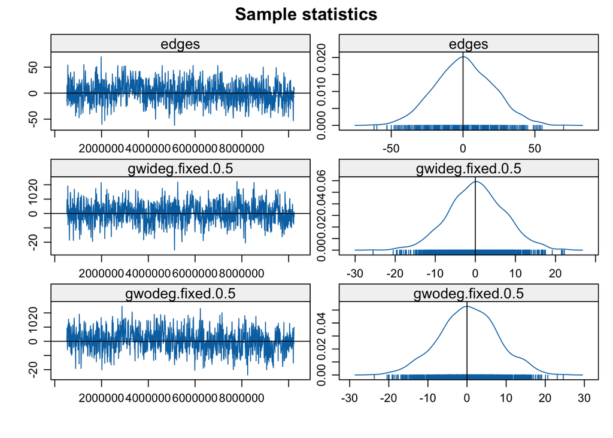

[figure not shown]

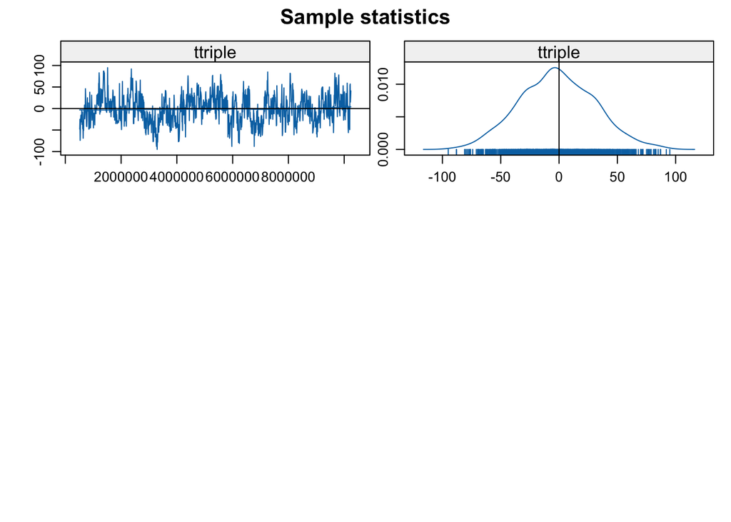

```
MCMC diagnostics shown here are from the last round of simulation, prior to computation of final parameter estimates. Because the final estimates are refinements of those used for this simulation run, these diagnostics may understate model performance. To directly assess the performance of the final…
```

```r
mcmc.diagnostics(fit_ppi3)
```

## References

- Hansell, S. (1984). Cooperative groups, weak ties, and the integration of peer friendships. *Social Psychology Quarterly*, 47(4), 316-328.
- Kadushin, C. (1995). Friendship among the French financial elite. *American Sociological Review*, 60, 202-221.
- Snijders, T.A.B., Pattison, P.E., Robins, G.L., & Handcock, M.S. (2006). New specifications for exponential random graph models. *Sociological Methodology*, 36(1), 99-153.
- Hunter, D.R., & Handcock, M.S. (2006). Inference in curved exponential family models for networks. *Journal of Computational and Graphical Statistics*, 15(3), 565-583.
- Blackburn, B., & Handcock, M. S. (2023). Practical network modeling via tapered exponential-family random graph models. *Journal of Computational and Graphical Statistics*, 32(2), 388-401.

*This tutorial is based on UCLA [STATS 218: Social Network Analysis](https://handcock.github.io/teaching/218/) taught by Prof [Mark Handcock](https://handcock.github.io/).*